# Optimal Treatment Analysis

## Outcome Variable

**Outcome Variable:** whz

## Predictor Variables

**Intervention Variable:** exclfeed3

**Adjustment Set:**

- arm
- sex
- brthmon
- W_mage
- meducyrs
- feducyrs
- hhwealth_quart
- hfoodsec
- W_mhtcm
- W_mwtkg
- W_mbmi
- vagbrth
- W_gagebrth
- W_birthwt
- W_birthlen
- W_nrooms
- W_nchldlt5
- month
- W_parity
- impfloor
- impsan
- safeh20
- delta_W_mage
- delta_meducyrs
- delta_feducyrs
- delta_hhwealth_quart
- delta_hfoodsec
- delta_W_mhtcm
- delta_W_mwtkg
- delta_W_mbmi
- delta_vagbrth
- delta_W_gagebrth
- delta_W_birthwt
- delta_W_birthlen
- delta_W_nrooms
- delta_W_nchldlt5
- delta_month
- delta_W_parity
- delta_impfloor
- delta_impsan
- delta_safeh20

## Stratifying Variables

The analysis was stratified on these variable(s):

- agecat
- studyid
- country

## Data Summary

| agecat | studyid | country | exclfeed3 | n_cell | n |
| --- | --- | --- | --- | --- | --- |
| Birth | CMC-V-BCS-2002 | INDIA | 1 | 4 | 4 |
| Birth | CMC-V-BCS-2002 | INDIA | 0 | 0 | 4 |
| Birth | EE | PAKISTAN | 1 | 22 | 22 |
| Birth | EE | PAKISTAN | 0 | 0 | 22 |
| Birth | GMS-Nepal | NEPAL | 1 | 352 | 422 |
| Birth | GMS-Nepal | NEPAL | 0 | 70 | 422 |
| Birth | IRC | INDIA | 1 | 0 | 9 |
| Birth | IRC | INDIA | 0 | 9 | 9 |
| Birth | JiVitA-3 | BANGLADESH | 1 | 9636 | 10634 |
| Birth | JiVitA-3 | BANGLADESH | 0 | 998 | 10634 |
| Birth | JiVitA-4 | BANGLADESH | 1 | 89 | 97 |
| Birth | JiVitA-4 | BANGLADESH | 0 | 8 | 97 |
| Birth | Keneba | GAMBIA | 1 | 1133 | 1282 |
| Birth | Keneba | GAMBIA | 0 | 149 | 1282 |
| Birth | MAL-ED | BANGLADESH | 1 | 130 | 202 |
| Birth | MAL-ED | BANGLADESH | 0 | 72 | 202 |
| Birth | MAL-ED | BRAZIL | 1 | 11 | 55 |
| Birth | MAL-ED | BRAZIL | 0 | 44 | 55 |
| Birth | MAL-ED | INDIA | 1 | 22 | 39 |
| Birth | MAL-ED | INDIA | 0 | 17 | 39 |
| Birth | MAL-ED | NEPAL | 1 | 8 | 25 |
| Birth | MAL-ED | NEPAL | 0 | 17 | 25 |
| Birth | MAL-ED | PERU | 1 | 47 | 218 |
| Birth | MAL-ED | PERU | 0 | 171 | 218 |
| Birth | MAL-ED | SOUTH AFRICA | 1 | 12 | 99 |
| Birth | MAL-ED | SOUTH AFRICA | 0 | 87 | 99 |
| Birth | MAL-ED | TANZANIA, UNITED REPUBLIC OF | 1 | 15 | 95 |
| Birth | MAL-ED | TANZANIA, UNITED REPUBLIC OF | 0 | 80 | 95 |
| Birth | PROVIDE | BANGLADESH | 1 | 381 | 532 |
| Birth | PROVIDE | BANGLADESH | 0 | 151 | 532 |

[output cut: 64 more lines]

The following strata were considered:

- agecat: 24 months, studyid: CMC-V-BCS-2002, country: INDIA
- agecat: 24 months, studyid: EE, country: PAKISTAN
- agecat: 24 months, studyid: GMS-Nepal, country: NEPAL
- agecat: 24 months, studyid: IRC, country: INDIA
- agecat: 24 months, studyid: JiVitA-3, country: BANGLADESH
- agecat: 24 months, studyid: JiVitA-4, country: BANGLADESH
- agecat: 24 months, studyid: Keneba, country: GAMBIA
- agecat: 24 months, studyid: MAL-ED, country: BANGLADESH
- agecat: 24 months, studyid: MAL-ED, country: BRAZIL
- agecat: 24 months, studyid: MAL-ED, country: INDIA
- agecat: 24 months, studyid: MAL-ED, country: NEPAL
- agecat: 24 months, studyid: MAL-ED, country: PERU
- agecat: 24 months, studyid: MAL-ED, country: SOUTH AFRICA
- agecat: 24 months, studyid: MAL-ED, country: TANZANIA, UNITED REPUBLIC OF
- agecat: 24 months, studyid: PROVIDE, country: BANGLADESH
- agecat: 6 months, studyid: CMC-V-BCS-2002, country: INDIA
- agecat: 6 months, studyid: EE, country: PAKISTAN
- agecat: 6 months, studyid: GMS-Nepal, country: NEPAL
- agecat: 6 months, studyid: IRC, country: INDIA
- agecat: 6 months, studyid: JiVitA-3, country: BANGLADESH
- agecat: 6 months, studyid: JiVitA-4, country: BANGLADESH
- agecat: 6 months, studyid: Keneba, country: GAMBIA
- agecat: 6 months, studyid: MAL-ED, country: BANGLADESH
- agecat: 6 months, studyid: MAL-ED, country: BRAZIL
- agecat: 6 months, studyid: MAL-ED, country: INDIA
- agecat: 6 months, studyid: MAL-ED, country: NEPAL
- agecat: 6 months, studyid: MAL-ED, country: PERU
- agecat: 6 months, studyid: MAL-ED, country: SOUTH AFRICA
- agecat: 6 months, studyid: MAL-ED, country: TANZANIA, UNITED REPUBLIC OF
- agecat: 6 months, studyid: PROVIDE, country: BANGLADESH
- agecat: 6 months, studyid: SAS-CompFeed, country: INDIA
- agecat: Birth, studyid: CMC-V-BCS-2002, country: INDIA
- agecat: Birth, studyid: EE, country: PAKISTAN
- agecat: Birth, studyid: GMS-Nepal, country: NEPAL
- agecat: Birth, studyid: IRC, country: INDIA
- agecat: Birth, studyid: JiVitA-3, country: BANGLADESH
- agecat: Birth, studyid: JiVitA-4, country: BANGLADESH
- agecat: Birth, studyid: Keneba, country: GAMBIA
- agecat: Birth, studyid: MAL-ED, country: BANGLADESH
- agecat: Birth, studyid: MAL-ED, country: BRAZIL
- agecat: Birth, studyid: MAL-ED, country: INDIA
- agecat: Birth, studyid: MAL-ED, country: NEPAL
- agecat: Birth, studyid: MAL-ED, country: PERU
- agecat: Birth, studyid: MAL-ED, country: SOUTH AFRICA
- agecat: Birth, studyid: MAL-ED, country: TANZANIA, UNITED REPUBLIC OF
- agecat: Birth, studyid: PROVIDE, country: BANGLADESH
- agecat: Birth, studyid: SAS-CompFeed, country: INDIA

### Dropped Strata

- agecat: Birth, studyid: CMC-V-BCS-2002, country: INDIA
- agecat: Birth, studyid: EE, country: PAKISTAN
- agecat: Birth, studyid: IRC, country: INDIA
- agecat: 6 months, studyid: CMC-V-BCS-2002, country: INDIA
- agecat: 6 months, studyid: EE, country: PAKISTAN
- agecat: 6 months, studyid: IRC, country: INDIA
- agecat: 24 months, studyid: CMC-V-BCS-2002, country: INDIA
- agecat: 24 months, studyid: EE, country: PAKISTAN
- agecat: 24 months, studyid: IRC, country: INDIA

## Methods Detail

We’re interested in the causal parameters $E[Y_a]$ for all values of $a \in \mathcal{A}$. These parameters represent the mean outcome if, possibly contrary to fact, we intervened to set all units to have $A=a$. Under the randomization and positivity assumptions, these are identified by the statistical parameters $\psi_a=E_W[E_{Y|A,W}(Y|A=a,W)]$. In addition, we’re interested in the mean of $Y$, $E[Y]$ under no intervention (the observed mean). We will estimate these parameters by using SuperLearner to fit the relevant likelihood factors – $E_{Y|A,W}(Y|A=a,W)$ and $p(A=a|W)$, and then updating our likelihood fit using a joint TMLE.

For unadjusted analyses ($W=\{\}$), initial likelihoods were estimated using Lrnr_glm to estimate the simple $E(Y|A)$ and Lrnr_mean to estimate $p(A)$. For adjusted analyses, a small library containing Lrnr_glmnet, Lrnr_xgboost, and Lrnr_mean was used.

Having estimated these parameters, we will then use the delta method to estimate relative risks and attributable risks relative to a prespecified baseline level of $A$.

# Results Detail

## Results Plots

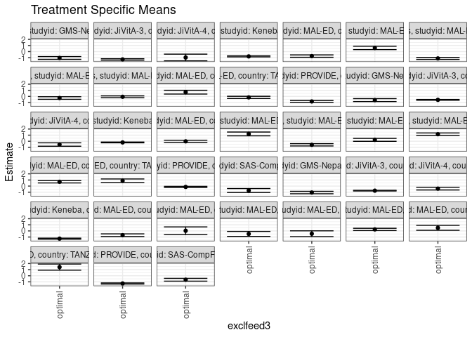

## Results Table

### Parameter: TSM

| agecat | studyid | country | intervention_level | baseline_level | estimate | ci_lower | ci_upper |
| --- | --- | --- | --- | --- | --- | --- | --- |
| Birth | GMS-Nepal | NEPAL | optimal | observed | -1.0572921 | -1.2568691 | -0.8577151 |
| Birth | JiVitA-3 | BANGLADESH | optimal | observed | -0.7498424 | -0.8037031 | -0.6959817 |
| Birth | JiVitA-4 | BANGLADESH | optimal | observed | -0.4158834 | -0.6385797 | -0.1931871 |
| Birth | Keneba | GAMBIA | optimal | observed | -1.2683690 | -1.3515765 | -1.1851615 |
| Birth | MAL-ED | BANGLADESH | optimal | observed | -0.7036628 | -0.9251014 | -0.4822242 |
| Birth | MAL-ED | BRAZIL | optimal | observed | 0.0271287 | -0.6047636 | 0.6590210 |
| Birth | MAL-ED | INDIA | optimal | observed | -0.4933206 | -0.9020254 | -0.0846158 |
| Birth | MAL-ED | NEPAL | optimal | observed | -0.4615289 | -0.9359456 | 0.0128878 |
| Birth | MAL-ED | PERU | optimal | observed | 0.2475497 | 0.0627320 | 0.4323675 |
| Birth | MAL-ED | SOUTH AFRICA | optimal | observed | 0.5068551 | 0.1030524 | 0.9106578 |
| Birth | MAL-ED | TANZANIA, UNITED REPUBLIC OF | optimal | observed | 1.4151661 | 0.9133730 | 1.9169592 |
| Birth | PROVIDE | BANGLADESH | optimal | observed | -1.2666835 | -1.3544496 | -1.1789174 |
| Birth | SAS-CompFeed | INDIA | optimal | observed | -0.6562835 | -0.8852815 | -0.4272855 |
| 6 months | GMS-Nepal | NEPAL | optimal | observed | -0.6033674 | -0.8437093 | -0.3630255 |
| 6 months | JiVitA-3 | BANGLADESH | optimal | observed | -0.5634309 | -0.6264063 | -0.5004555 |
| 6 months | JiVitA-4 | BANGLADESH | optimal | observed | -0.5375392 | -0.8157437 | -0.2593347 |
| 6 months | Keneba | GAMBIA | optimal | observed | -0.1946978 | -0.2564022 | -0.1329935 |
| 6 months | MAL-ED | BANGLADESH | optimal | observed | -0.0139535 | -0.1926031 | 0.1646960 |
| 6 months | MAL-ED | BRAZIL | optimal | observed | 1.1987178 | 0.8884236 | 1.5090120 |
| 6 months | MAL-ED | INDIA | optimal | observed | -0.5842590 | -0.7757891 | -0.3927290 |
| 6 months | MAL-ED | NEPAL | optimal | observed | 0.2304215 | -0.0092875 | 0.4701304 |
| 6 months | MAL-ED | PERU | optimal | observed | 1.1541453 | 0.9509600 | 1.3573305 |
| 6 months | MAL-ED | SOUTH AFRICA | optimal | observed | 0.7025834 | 0.5158235 | 0.8893434 |
| 6 months | MAL-ED | TANZANIA, UNITED REPUBLIC OF | optimal | observed | 0.8769658 | 0.5850700 | 1.1688617 |
| 6 months | PROVIDE | BANGLADESH | optimal | observed | -0.1386241 | -0.2324962 | -0.0447520 |
| 6 months | SAS-CompFeed | INDIA | optimal | observed | -0.7249143 | -1.0477394 | -0.4020893 |
| 24 months | GMS-Nepal | NEPAL | optimal | observed | -1.0461150 | -1.2727054 | -0.8195246 |
| 24 months | JiVitA-3 | BANGLADESH | optimal | observed | -1.2860733 | -1.4037333 | -1.1684134 |
| 24 months | JiVitA-4 | BANGLADESH | optimal | observed | -0.9709483 | -1.5200946 | -0.4218020 |
| 24 months | Keneba | GAMBIA | optimal | observed | -0.7899581 | -0.8729725 | -0.7069438 |
| 24 months | MAL-ED | BANGLADESH | optimal | observed | -0.7419264 | -0.9374016 | -0.5464512 |
| 24 months | MAL-ED | BRAZIL | optimal | observed | 0.5968959 | 0.3233243 | 0.8704674 |
| 24 months | MAL-ED | INDIA | optimal | observed | -1.1197990 | -1.2873916 | -0.9522065 |
| 24 months | MAL-ED | NEPAL | optimal | observed | -0.2622900 | -0.4756078 | -0.0489723 |
| 24 months | MAL-ED | PERU | optimal | observed | -0.0641243 | -0.2172422 | 0.0889936 |
| 24 months | MAL-ED | SOUTH AFRICA | optimal | observed | 0.6942427 | 0.3850133 | 1.0034722 |
| 24 months | MAL-ED | TANZANIA, UNITED REPUBLIC OF | optimal | observed | -0.1611474 | -0.3437707 | 0.0214760 |
| 24 months | PROVIDE | BANGLADESH | optimal | observed | -0.8250652 | -0.9813180 | -0.6688125 |

### Parameter: E(Y)

| agecat | studyid | country | intervention_level | baseline_level | estimate | ci_lower | ci_upper |
| --- | --- | --- | --- | --- | --- | --- | --- |
| Birth | GMS-Nepal | NEPAL | observed | observed | -1.0991706 | -1.2073693 | -0.9909719 |
| Birth | JiVitA-3 | BANGLADESH | observed | observed | -0.7798636 | -0.8022140 | -0.7575133 |
| Birth | JiVitA-4 | BANGLADESH | observed | observed | -0.4347423 | -0.6441144 | -0.2253701 |
| Birth | Keneba | GAMBIA | observed | observed | -1.2629563 | -1.3291505 | -1.1967622 |
| Birth | MAL-ED | BANGLADESH | observed | observed | -0.9411386 | -1.0895370 | -0.7927402 |
| Birth | MAL-ED | BRAZIL | observed | observed | 0.4316364 | 0.0969688 | 0.7663039 |
| Birth | MAL-ED | INDIA | observed | observed | -0.9779487 | -1.2664810 | -0.6894164 |
| Birth | MAL-ED | NEPAL | observed | observed | -0.7944000 | -1.1625222 | -0.4262778 |
| Birth | MAL-ED | PERU | observed | observed | -0.0335321 | -0.1564905 | 0.0894263 |
| Birth | MAL-ED | SOUTH AFRICA | observed | observed | -0.1588889 | -0.3845288 | 0.0667510 |
| Birth | MAL-ED | TANZANIA, UNITED REPUBLIC OF | observed | observed | 0.7996842 | 0.5874808 | 1.0118876 |
| Birth | PROVIDE | BANGLADESH | observed | observed | -1.2984586 | -1.3752758 | -1.2216415 |
| Birth | SAS-CompFeed | INDIA | observed | observed | -0.6596308 | -0.9005716 | -0.4186900 |
| 6 months | GMS-Nepal | NEPAL | observed | observed | -0.6198791 | -0.7206518 | -0.5191063 |
| 6 months | JiVitA-3 | BANGLADESH | observed | observed | -0.6040977 | -0.6286619 | -0.5795335 |
| 6 months | JiVitA-4 | BANGLADESH | observed | observed | -0.4110227 | -0.6122701 | -0.2097753 |
| 6 months | Keneba | GAMBIA | observed | observed | -0.2057183 | -0.2614359 | -0.1500006 |
| 6 months | MAL-ED | BANGLADESH | observed | observed | -0.1304936 | -0.2625419 | 0.0015547 |
| 6 months | MAL-ED | BRAZIL | observed | observed | 0.9754144 | 0.7990651 | 1.1517638 |
| 6 months | MAL-ED | INDIA | observed | observed | -0.7185992 | -0.8491469 | -0.5880515 |
| 6 months | MAL-ED | NEPAL | observed | observed | 0.1041483 | -0.0311352 | 0.2394318 |
| 6 months | MAL-ED | PERU | observed | observed | 1.0514136 | 0.9289176 | 1.1739096 |
| 6 months | MAL-ED | SOUTH AFRICA | observed | observed | 0.5564071 | 0.4055220 | 0.7072922 |
| 6 months | MAL-ED | TANZANIA, UNITED REPUBLIC OF | observed | observed | 0.5257626 | 0.3871543 | 0.6643709 |
| 6 months | PROVIDE | BANGLADESH | observed | observed | -0.1990907 | -0.2817968 | -0.1163845 |
| 6 months | SAS-CompFeed | INDIA | observed | observed | -0.6348861 | -0.7630511 | -0.5067211 |
| 24 months | GMS-Nepal | NEPAL | observed | observed | -1.1396441 | -1.2416403 | -1.0376479 |
| 24 months | JiVitA-3 | BANGLADESH | observed | observed | -1.3109518 | -1.3423299 | -1.2795737 |
| 24 months | JiVitA-4 | BANGLADESH | observed | observed | -1.0096000 | -1.1619164 | -0.8572836 |
| 24 months | Keneba | GAMBIA | observed | observed | -0.7930925 | -0.8442611 | -0.7419240 |
| 24 months | MAL-ED | BANGLADESH | observed | observed | -0.8076829 | -0.9296166 | -0.6857493 |
| 24 months | MAL-ED | BRAZIL | observed | observed | 0.4981140 | 0.2760418 | 0.7201863 |
| 24 months | MAL-ED | INDIA | observed | observed | -0.9516832 | -1.0703961 | -0.8329703 |
| 24 months | MAL-ED | NEPAL | observed | observed | -0.3790455 | -0.4958857 | -0.2622052 |
| 24 months | MAL-ED | PERU | observed | observed | 0.1176052 | -0.0015211 | 0.2367315 |
| 24 months | MAL-ED | SOUTH AFRICA | observed | observed | 0.4120797 | 0.2900939 | 0.5340654 |
| 24 months | MAL-ED | TANZANIA, UNITED REPUBLIC OF | observed | observed | 0.0495743 | -0.0857535 | 0.1849021 |
| 24 months | PROVIDE | BANGLADESH | observed | observed | -0.8928670 | -0.9755153 | -0.8102187 |

### Parameter: PAR

| agecat | studyid | country | intervention_level | baseline_level | estimate | ci_lower | ci_upper |
| --- | --- | --- | --- | --- | --- | --- | --- |
| Birth | GMS-Nepal | NEPAL | optimal | observed | -0.0418785 | -0.2190953 | 0.1353383 |
| Birth | JiVitA-3 | BANGLADESH | optimal | observed | -0.0300213 | -0.0790471 | 0.0190046 |
| Birth | JiVitA-4 | BANGLADESH | optimal | observed | -0.0188589 | -0.0623536 | 0.0246357 |
| Birth | Keneba | GAMBIA | optimal | observed | 0.0054127 | -0.0476064 | 0.0584318 |
| Birth | MAL-ED | BANGLADESH | optimal | observed | -0.2374759 | -0.4026407 | -0.0723110 |
| Birth | MAL-ED | BRAZIL | optimal | observed | 0.4045077 | -0.1444061 | 0.9534214 |
| Birth | MAL-ED | INDIA | optimal | observed | -0.4846281 | -0.7911583 | -0.1780980 |
| Birth | MAL-ED | NEPAL | optimal | observed | -0.3328711 | -0.8228964 | 0.1571542 |
| Birth | MAL-ED | PERU | optimal | observed | -0.2810818 | -0.4507122 | -0.1114515 |
| Birth | MAL-ED | SOUTH AFRICA | optimal | observed | -0.6657440 | -1.0608719 | -0.2706161 |
| Birth | MAL-ED | TANZANIA, UNITED REPUBLIC OF | optimal | observed | -0.6154819 | -1.0971214 | -0.1338424 |
| Birth | PROVIDE | BANGLADESH | optimal | observed | -0.0317752 | -0.0762713 | 0.0127210 |
| Birth | SAS-CompFeed | INDIA | optimal | observed | -0.0033473 | -0.0446450 | 0.0379504 |
| 6 months | GMS-Nepal | NEPAL | optimal | observed | -0.0165117 | -0.2218570 | 0.1888337 |
| 6 months | JiVitA-3 | BANGLADESH | optimal | observed | -0.0406668 | -0.0988177 | 0.0174840 |
| 6 months | JiVitA-4 | BANGLADESH | optimal | observed | 0.1265165 | -0.1079902 | 0.3610232 |
| 6 months | Keneba | GAMBIA | optimal | observed | -0.0110205 | -0.0393386 | 0.0172977 |
| 6 months | MAL-ED | BANGLADESH | optimal | observed | -0.1165400 | -0.2404329 | 0.0073529 |
| 6 months | MAL-ED | BRAZIL | optimal | observed | -0.2233034 | -0.4775890 | 0.0309823 |
| 6 months | MAL-ED | INDIA | optimal | observed | -0.1343402 | -0.2664828 | -0.0021975 |
| 6 months | MAL-ED | NEPAL | optimal | observed | -0.1262731 | -0.3258182 | 0.0732719 |
| 6 months | MAL-ED | PERU | optimal | observed | -0.1027317 | -0.2806914 | 0.0752280 |
| 6 months | MAL-ED | SOUTH AFRICA | optimal | observed | -0.1461763 | -0.3366789 | 0.0443263 |
| 6 months | MAL-ED | TANZANIA, UNITED REPUBLIC OF | optimal | observed | -0.3512033 | -0.5930517 | -0.1093548 |
| 6 months | PROVIDE | BANGLADESH | optimal | observed | -0.0604666 | -0.1160098 | -0.0049233 |
| 6 months | SAS-CompFeed | INDIA | optimal | observed | 0.0900283 | -0.2741145 | 0.4541710 |
| 24 months | GMS-Nepal | NEPAL | optimal | observed | -0.0935291 | -0.2913204 | 0.1042621 |
| 24 months | JiVitA-3 | BANGLADESH | optimal | observed | -0.0248784 | -0.1346603 | 0.0849034 |
| 24 months | JiVitA-4 | BANGLADESH | optimal | observed | -0.0386517 | -0.5639195 | 0.4866161 |
| 24 months | Keneba | GAMBIA | optimal | observed | -0.0031344 | -0.0647622 | 0.0584934 |
| 24 months | MAL-ED | BANGLADESH | optimal | observed | -0.0657565 | -0.2051994 | 0.0736863 |
| 24 months | MAL-ED | BRAZIL | optimal | observed | -0.0987818 | -0.2587352 | 0.0611715 |
| 24 months | MAL-ED | INDIA | optimal | observed | 0.1681159 | 0.0474774 | 0.2887543 |
| 24 months | MAL-ED | NEPAL | optimal | observed | -0.1167554 | -0.2946227 | 0.0611118 |
| 24 months | MAL-ED | PERU | optimal | observed | 0.1817295 | 0.0499802 | 0.3134788 |
| 24 months | MAL-ED | SOUTH AFRICA | optimal | observed | -0.2821631 | -0.5947846 | 0.0304585 |
| 24 months | MAL-ED | TANZANIA, UNITED REPUBLIC OF | optimal | observed | 0.2107216 | 0.0503586 | 0.3710847 |
| 24 months | PROVIDE | BANGLADESH | optimal | observed | -0.0678018 | -0.1966958 | 0.0610922 |